# Machine Learning

Shelbi

2/6/2021

## Overview

This assignment uses the data from the Groupware Human Activity Recognition data (http://groupware.les.inf.puc-rio.br/har). The data used specifically for this assignment was for the barbell lifting exercise. Six participants were asked to perform barbell lifts correctly and incorrectly in 5 different ways while wearing fitness monitors on the belt, forearm, arm and dumbbell.

The goal of this assignment is to be able to classify or predict the manner in which the participant completed the exercise (classe variable).

Classe A = specified execution of the exercise

Classe B = throwing the elbows to the front

Classe C = lifting the dumbbell only halfway

Classe D = lowering the dumbbell only halfway

Classe E = throwing the hips to the front

## Preparations

First items completed was loading necessary librarys and data sets into R and preparing the data for testing.

```r
library(caret)
library (randomForest)
library(rpart)

testing <- read.csv("pml-testing.csv", header = TRUE, sep = ",", na.strings = c("NA", ""))
training <- read.csv("pml-training.csv", header = TRUE, sep = ",", na.strings = c("NA", ""))
```

```r
trainingData<-training[,colSums(is.na(training)) == 0]
testingData <-testing[,colSums(is.na(testing)) == 0]
```

Additionally, the first seven columns in the data sets were determined to not be neccessary for the prediction model. These were removed from the training and testing sets as well.

```r
trainingData   <-trainingData[,-c(1:7)]
testingData <-testingData[,-c(1:7)]
```

To perform cross-validation, the trainingData data set was subset into subtraining and subtesting sets using random sampling. We will build our model on the sub-training set and then evaluate this model on the sub-testing set.

The seed was set to 1233 for all models for reproducability.

```r
set.seed(1233)

inTrain<- createDataPartition(trainingData$classe, p=.70,  list = FALSE)

subTrain<-trainingData[inTrain,]
subTest<- trainingData[-inTrain,]
```

To be able to perform the tests the “classe” variable in the subTrain and subTest sets was converted from a character class to factor.

```r
subTrain$classe<-as.factor(subTrain$classe)
subTest$classe<-as.factor(subTest$classe)
```

Before testing, let’s get an overview of the data.

```r
Perc<- prop.table((table(subTrain$classe))*100)
cbind(freq=table(subTrain$classe), Perc = Perc)
```

```
##   freq      Perc
## A 3906 0.2843416
## B 2658 0.1934920
## C 2396 0.1744195
## D 2252 0.1639368
## E 2525 0.1838101
```

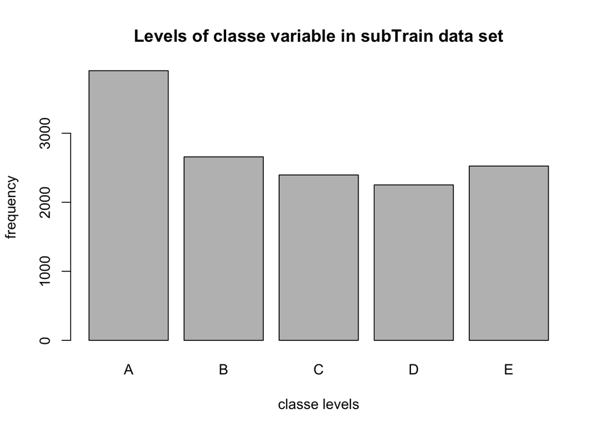

```r
plot(subTrain$classe, main = "Levels of classe variable in subTrain data set", ylab = "frequency", xlab = "classe levels")
```

We can see here that each level of the classe variable are close in number of frequency. There are clearly more of Class A.

```r
dim(subTrain)
```

```
## [1] 13737    53
```

We will be testing on 52 predictor variables to predict Classe. All are continuous variable except for our target variable (classe).

## Models

### Decision Tree

Because we are attempting to classify our target variable based on a set of continuous predictor variables, it was decided to first attempt to create the model with a Decision Tree.

```r
tree<- rpart(classe~., data = subTrain, method = "class")
TreePredict<- predict(tree, subTest, type="class")
confusionMatrix(TreePredict, subTest$classe)
```

```
## Confusion Matrix and Statistics
##
##           Reference
## Prediction    A    B    C    D    E
##          A 1554  244   63  155   50
##          B   44  644   44   29   64
##          C   40   95  781  140  129
##          D   22   82   77  538   50
##          E   14   74   61  102  789
##
## Overall Statistics
##
##                Accuracy : 0.7317
##                  95% CI : (0.7202, 0.743)
##     No Information Rate : 0.2845
##     P-Value [Acc > NIR] : < 2.2e-16
##
##                   Kappa : 0.6578
##
##  Mcnemar's Test P-Value : < 2.2e-16
##
## Statistics by Class:
##
##                      Class: A Class: B Class: C Class: D Class: E
## Sensitivity            0.9283   0.5654   0.7612  0.55809   0.7292
## Specificity            0.8784   0.9619   0.9169  0.95306   0.9477
## Pos Pred Value         0.7522   0.7806   0.6591  0.69961   0.7587
## Neg Pred Value         0.9686   0.9022   0.9479  0.91673   0.9395
## Prevalence             0.2845   0.1935   0.1743  0.16381   0.1839
## Detection Rate         0.2641   0.1094   0.1327  0.09142   0.1341
## Detection Prevalence   0.3511   0.1402   0.2014  0.13067   0.1767
## Balanced Accuracy      0.9034   0.7636   0.8390  0.75557   0.8385
```

Unfortunately, we can see here that the accuracy of the prediction on our subTest data was only 73%. This might be because decision trees can be prone to over fitting.

### Random Forest

To attempt to get better accuracy and decrease our out of sample error, we attempted a Random Forest model which is less prone to over fitting.

```r
forest<- randomForest(classe~., data = subTrain, method= "class")
subPredict<- predict(forest, subTest, type = "class")
confusionMatrix(subPredict, subTest$classe)
```

```
## Confusion Matrix and Statistics
##
##           Reference
## Prediction    A    B    C    D    E
##          A 1674    9    0    0    0
##          B    0 1129    1    0    0
##          C    0    1 1024    7    2
##          D    0    0    1  956    4
##          E    0    0    0    1 1076
##
## Overall Statistics
##
##                Accuracy : 0.9956
##                  95% CI : (0.9935, 0.9971)
##     No Information Rate : 0.2845
##     P-Value [Acc > NIR] : < 2.2e-16
##
##                   Kappa : 0.9944
##
##  Mcnemar's Test P-Value : NA
##
## Statistics by Class:
##
##                      Class: A Class: B Class: C Class: D Class: E
## Sensitivity            1.0000   0.9912   0.9981   0.9917   0.9945
## Specificity            0.9979   0.9998   0.9979   0.9990   0.9998
## Pos Pred Value         0.9947   0.9991   0.9903   0.9948   0.9991
## Neg Pred Value         1.0000   0.9979   0.9996   0.9984   0.9988
## Prevalence             0.2845   0.1935   0.1743   0.1638   0.1839
## Detection Rate         0.2845   0.1918   0.1740   0.1624   0.1828
## Detection Prevalence   0.2860   0.1920   0.1757   0.1633   0.1830
## Balanced Accuracy      0.9989   0.9955   0.9980   0.9953   0.9971
```

We can see here that our accuracy is much higher (99.56%). Additionally, our Positive and Negative predictive values are much closer to 1 for all classes as compared to the Decision Tree model. This will be the final model used for our final testing.

### Final Test

```r
finalTest<- predict(forest, testing, type = "class")
finalTest
```

```
##  1  2  3  4  5  6  7  8  9 10 11 12 13 14 15 16 17 18 19 20
##  B  A  B  A  A  E  D  B  A  A  B  C  B  A  E  E  A  B  B  B
## Levels: A B C D E
```